# Human Activity Recognition using Random Forest Algorithm

Muhammad Mohsin Raza Danish

Sunday, 16 October 2016

## Summary

This assignment is about the machine learning applied to a dataset from [Human Activity Recognition](http://groupware.les.inf.puc-rio.br/har).

The HAR dataset contains accelerometer data collected from sensors on the belt, forearm, arm, and dumbell from 6 subjects that were asked to perform barbell lifts correctly and incorrectly in 5 different ways (sitting-down, standing-up, standing, walking, and sitting).

A random forest model was built with 300 trees using 5-fold cross-validation. and achieved an accuracy on the validation data of 99.36% with an out of sample error of 0.64%.

## Load Data

Training & testing datasets are loaded from [Groupware@LES Human Activity Recognition](http://groupware.les.inf.puc-rio.br/har).

```r
training <- read.csv("https://d396qusza40orc.cloudfront.net/predmachlearn/pml-training.csv")
testing <- read.csv("https://d396qusza40orc.cloudfront.net/predmachlearn/pml-testing.csv")
```

## Explore data

```r
dim.trn <- dim(training)
dim.tst <- dim(testing)
```

The training data set contains 19622 observations and 160 variables and the test data set contains 20 observations and 160 variables.

The response variable is called `classe` and consists of 5 factors.

A-E represent these activities: - sitting-down - standing-up - standing - walking - sitting

The summary of the `classe` response for the training dataset is as follows.

```r
summary(training$classe)
```

```
##    A    B    C    D    E
## 5580 3797 3422 3216 3607
```

## Preprocess Data

### Remove varables with NA’s

We start with getting rid of the columns with NA’s:

```r
sum(complete.cases(training))
```

```
## [1] 406
```

```r
training.2 <- training[, colSums(is.na(training)) == 0]
dim(training.2)
```

```
## [1] 19622    93
```

### Remove variables with near zero variance

Then, we remove the columns with zero or near zero variance.

```r
nzv <- nearZeroVar(training.2, saveMetrics=TRUE)
training.3 <- training.2[, nzv[,"nzv"] == FALSE]
dim(training.3)
```

```
## [1] 19622    59
```

### Remove non-accelerator columns

There are a few non-accelerator variables we can also remove, such as timestamp, user, window etc.

```r
training.4 <- training.3[, -grep("timestamp|user_name|new_window|num_window|X", names(training.3))]
dim.trn4 <- dim(training.4)
```

The reduced training dataset now contains 19622 observations and 53 variables.

## Data Model

Next, we fit a random forest model with 5-fold cross validation for a good bias-variance trade-off. The cleaned training dataset is split 80/20 into a training & validation dataset.

```r
set.seed(1122)
inTrain <- createDataPartition(training.4$classe, p=0.8, list=FALSE)
training.data <- training.4[inTrain,]
validation.data <- training.4[-inTrain, ]

# Use multiple cores for parallel processing
num.cores <- detectCores()
registerDoMC(cores = num.cores - 1)

model.RF <- train(classe ~ .,
                 data=training.data, method="rf",
                 trControl=trainControl(method="cv", number=5),
                 prox=TRUE,
                 allowParallel=TRUE,
                 ntree=300)
model.RF
```

```
## Random Forest
##
## 15699 samples
##    52 predictor
##     5 classes: 'A', 'B', 'C', 'D', 'E'
##
## No pre-processing
## Resampling: Cross-Validated (5 fold)
## Summary of sample sizes: 12560, 12562, 12559, 12558, 12557
## Resampling results across tuning parameters:
##
##   mtry  Accuracy   Kappa
##    2    0.9914013  0.9891216
##   27    0.9917190  0.9895236
##   52    0.9850951  0.9811440
##
## Accuracy was used to select the optimal model using  the largest value.
## The final value used for the model was mtry = 27.
```

### Estimated accuracy & out of sample error of the model

The model is tested on the validation dataset:

```r
predict.RF <- predict(model.RF, validation.data)
confusionMatrix(validation.data$classe, predict.RF)
```

```
## Confusion Matrix and Statistics
##
##           Reference
## Prediction    A    B    C    D    E
##          A 1113    1    1    0    1
##          B    6  752    1    0    0
##          C    0    6  676    2    0
##          D    0    0    5  638    0
##          E    0    0    0    2  719
##
## Overall Statistics
##
##                Accuracy : 0.9936
##                  95% CI : (0.9906, 0.9959)
##     No Information Rate : 0.2852
##     P-Value [Acc > NIR] : < 2.2e-16
##
##                   Kappa : 0.9919
##  Mcnemar's Test P-Value : NA
##
## Statistics by Class:
##
##                      Class: A Class: B Class: C Class: D Class: E
## Sensitivity            0.9946   0.9908   0.9898   0.9938   0.9986
## Specificity            0.9989   0.9978   0.9975   0.9985   0.9994
## Pos Pred Value         0.9973   0.9908   0.9883   0.9922   0.9972
## Neg Pred Value         0.9979   0.9978   0.9978   0.9988   0.9997
## Prevalence             0.2852   0.1935   0.1741   0.1637   0.1835
## Detection Rate         0.2837   0.1917   0.1723   0.1626   0.1833
## Detection Prevalence   0.2845   0.1935   0.1744   0.1639   0.1838
## Balanced Accuracy      0.9968   0.9943   0.9936   0.9961   0.9990
```

The out of sample error should be low as the random forest algorithm performs cross-validation internally.

```r
out.of.sample.error <- sum(predict.RF != validation.data$classe) * 100 / nrow(validation.data)
```

The estimated accuracy of the model on the validation dataset is 99.36% and the estimated out of sample error is 0.64%.

See the appendix for plots of predictor importance, model accuracy for selected predictors and the error rate for the number of trees in the random forest.

## Predition result on the testing dataset

The result of applying the testing dataset on the model:

```r
# ind.col <- which(names(testing) %in% names(training.4))
# ind.col
test.data <- testing[, names(testing) %in% names(training.4)]
predict.RF.Test <- predict(model.RF, newdata=test.data)
predict.RF.Test
```

```
##  [1] B A B A A E D B A A B C B A E E A B B B
## Levels: A B C D E
```

## Conclusion

I ran the training algorithm for several number of trees. I find that the accuracy was varying slightly for different number of trees. Similar accuracy can also be achieved with less number of trees. The current setting gives a good model and in general, we can tune the paramters such as the number of trees to get the desired accuracy.

## Appendix

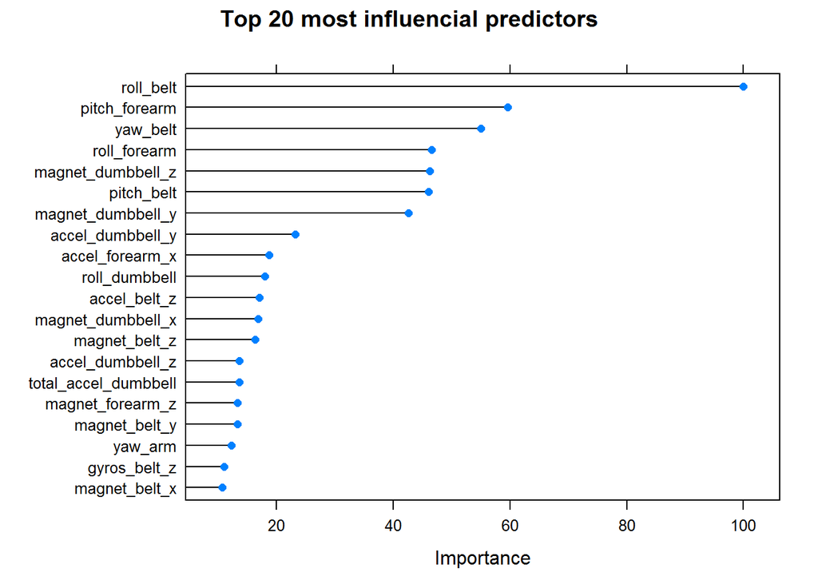

```r
vi <- varImp(model.RF)
plot(vi, main = "Top 20 most influencial predictors", top = 20)
```

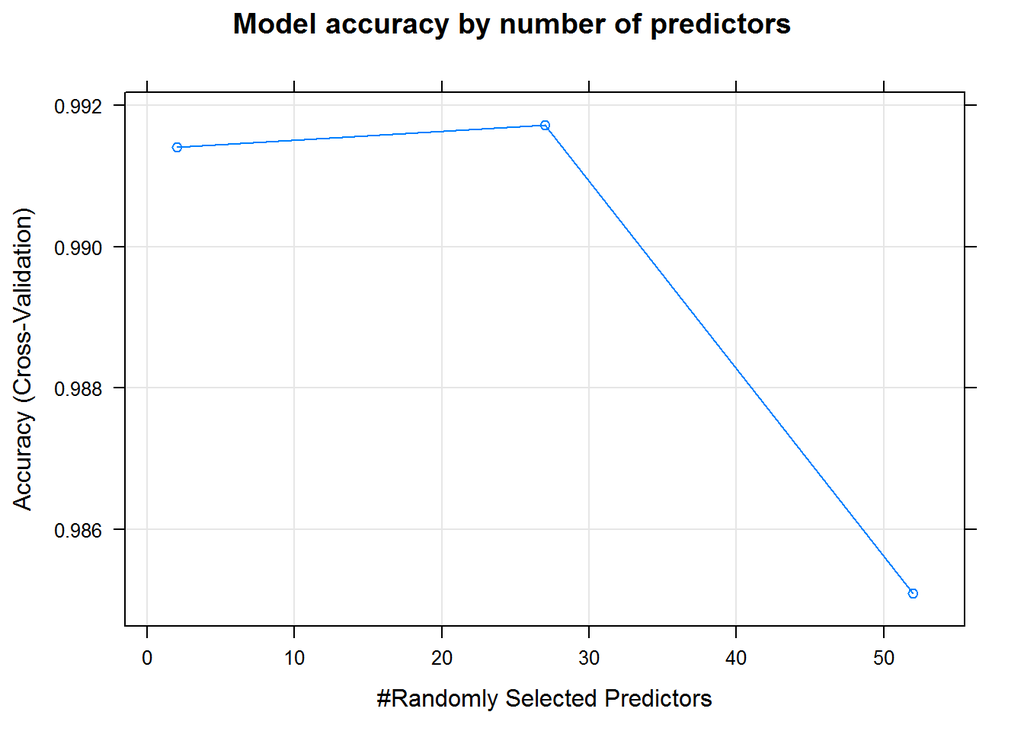

```r
plot(model.RF, main="Model accuracy by number of predictors")
```

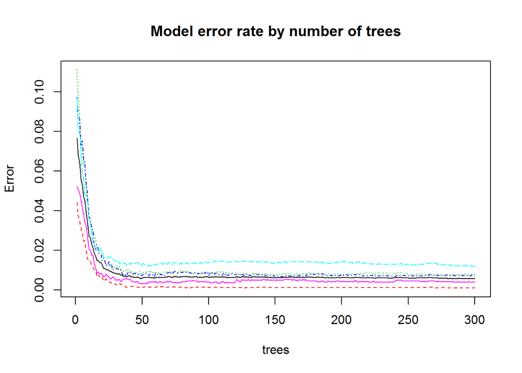

```r
plot(model.RF$finalModel, main="Model error rate by number of trees")
```